# BankChurn Data Project / Yeoman Yoon

```python
#!pip install tensorflow
```

```python
import pandas as pd
import numpy as np
from sklearn import metrics
import matplotlib.pyplot as plt
%matplotlib inline
import seaborn as sns
from sklearn.preprocessing import StandardScaler
from sklearn import metrics
from sklearn import preprocessing
from sklearn.metrics import accuracy_score, confusion_matrix, precision_score, recall_score, f1_score, precision_recall_curve, auc
from sklearn.decomposition import PCA

#model
from sklearn.model_selection import train_test_split
#CV
from sklearn.model_selection import cross_val_score
from sklearn.datasets import make_classification

#Tensorflow
import tensorflow as tf
from tensorflow.keras.models import Sequential
from tensorflow.keras.layers import Dense, Dropout
from tensorflow.keras import optimizers

#Keras
import keras
from keras import backend as K
from keras.models import Sequential
from keras.layers import Dense, Dropout
from keras.optimizers import Adam
from keras import layers
from keras.wrappers.scikit_learn import KerasClassifier
```

## Import Data

```python
bank = pd.read_csv("bank.csv") # use copy to store the original data
data = bank.copy()
```

```python
data.head()
```

|  | RowNumber | CustomerId | Surname | CreditScore | Geography | Gender | Age | Tenure | Balance | NumOfProducts | HasCrCard | IsActiveMember | EstimatedSalary | Exited |
| --- | --- | --- | --- | --- | --- | --- | --- | --- | --- | --- | --- | --- | --- | --- |
| 0 | 1 | 15634602 | Hargrave | 619 | France | Female | 42 | 2 | 0.00 | 1 | 1 | 1 | 101348.88 | 1 |
| 1 | 2 | 15647311 | Hill | 608 | Spain | Female | 41 | 1 | 83807.86 | 1 | 0 | 1 | 112542.58 | 0 |
| 2 | 3 | 15619304 | Onio | 502 | France | Female | 42 | 8 | 159660.80 | 3 | 1 | 0 | 113931.57 | 1 |
| 3 | 4 | 15701354 | Boni | 699 | France | Female | 39 | 1 | 0.00 | 2 | 0 | 0 | 93826.63 | 0 |
| 4 | 5 | 15737888 | Mitchell | 850 | Spain | Female | 43 | 2 | 125510.82 | 1 | 1 | 1 | 79084.10 | 0 |

```python
print(f"The data has {data.shape[0]} rows and {data.shape[1]} columns")
```

```
The data has 10000 rows and 14 columns
```

```python
data.info()
```

```
<class 'pandas.core.frame.DataFrame'>
RangeIndex: 10000 entries, 0 to 9999
Data columns (total 14 columns):
RowNumber          10000 non-null int64
CustomerId         10000 non-null int64
Surname            10000 non-null object
CreditScore        10000 non-null int64
Geography          10000 non-null object
Gender             10000 non-null object
Age                10000 non-null int64
Tenure             10000 non-null int64
Balance            10000 non-null float64
NumOfProducts      10000 non-null int64
HasCrCard          10000 non-null int64
IsActiveMember     10000 non-null int64
EstimatedSalary    10000 non-null float64
Exited             10000 non-null int64
dtypes: float64(2), int64(9), object(3)
memory usage: 1.1+ MB
```

Data does not have any missing values

## Data Dictionary

Data Dictionary:

1. CustomerId: Unique ID which is assigned to each customer
2. Surname: Last name of the customer
3. CreditScore: It defines the credit history of the customer.
4. Geography: A customer’s location
5. Gender: It defines the Gender of the customer
6. Age: Age of the customer
7. Tenure: Number of years for which the customer has been with the bank
8. NumOfProducts: It refers to the number of products that a customer has purchased through the bank.
9. Balance: Account balance
10. HasCrCard: It is a categorical variable that decides whether the customer has a credit card or not.
11. EstimatedSalary: Estimated salary
12. isActiveMember: It is a categorical variable that decides whether the customer is an active member of the bank or not ( Active member in the sense, using bank products regularly, making transactions, etc )
13. Excited: It is a categorical variable that decides whether the customer left the bank within six months or not. It can take two values (Predicted value)

```python
# Drop customer unique info, these are meaningless data in machine learning
data.drop(['RowNumber','CustomerId',"Surname"], axis=1, inplace = True)
```

```python
data.info()
```

```
<class 'pandas.core.frame.DataFrame'>
RangeIndex: 10000 entries, 0 to 9999
Data columns (total 11 columns):
CreditScore        10000 non-null int64
Geography          10000 non-null object
Gender             10000 non-null object
Age                10000 non-null int64
Tenure             10000 non-null int64
Balance            10000 non-null float64
NumOfProducts      10000 non-null int64
HasCrCard          10000 non-null int64
IsActiveMember     10000 non-null int64
EstimatedSalary    10000 non-null float64
Exited             10000 non-null int64
dtypes: float64(2), int64(7), object(2)
memory usage: 859.5+ KB
```

```python
data.nunique().sort_values(ascending=False)
```

```
EstimatedSalary    9999
Balance            6382
CreditScore         460
Age                  70
Tenure               11
NumOfProducts         4
Geography             3
Exited                2
IsActiveMember        2
HasCrCard             2
Gender                2
dtype: int64
```

Data Binning may be needed for Salary, Balance, CreditScore, and Age

## Datatype Conversion

For the memory purpose, Convert object and unique values to category.  
Skip this line to see correlation scores with integer ( data.describe() )

```python
to_category = ['Geography', 'Gender']

for col in to_category:
    data[col]=data[col].astype('category')
```

```python
# to_category1 = ['NumOfProducts', 'HasCrCard', 'IsActiveMember', 'Exited']
# for col in to_category1:
#     data[col]=data[col].astype('category')
```

## EDA

### Univariate EDA:

```python
data.describe().T
```

|  | count | mean | std | min | 25% | 50% | 75% | max |
| --- | --- | --- | --- | --- | --- | --- | --- | --- |
| CreditScore | 10000.0 | 650.528800 | 96.653299 | 350.00 | 584.00 | 652.000 | 718.0000 | 850.00 |
| Age | 10000.0 | 38.921800 | 10.487806 | 18.00 | 32.00 | 37.000 | 44.0000 | 92.00 |
| Tenure | 10000.0 | 5.012800 | 2.892174 | 0.00 | 3.00 | 5.000 | 7.0000 | 10.00 |
| Balance | 10000.0 | 76485.889288 | 62397.405202 | 0.00 | 0.00 | 97198.540 | 127644.2400 | 250898.09 |
| NumOfProducts | 10000.0 | 1.530200 | 0.581654 | 1.00 | 1.00 | 1.000 | 2.0000 | 4.00 |
| HasCrCard | 10000.0 | 0.705500 | 0.455840 | 0.00 | 0.00 | 1.000 | 1.0000 | 1.00 |
| IsActiveMember | 10000.0 | 0.515100 | 0.499797 | 0.00 | 0.00 | 1.000 | 1.0000 | 1.00 |
| EstimatedSalary | 10000.0 | 100090.239881 | 57510.492818 | 11.58 | 51002.11 | 100193.915 | 149388.2475 | 199992.48 |
| Exited | 10000.0 | 0.203700 | 0.402769 | 0.00 | 0.00 | 0.000 | 0.0000 | 1.00 |

```python
boxplot_col = ['Tenure','EstimatedSalary','Balance']
distplot_col = ['Age','CreditScore']
cat_col = ['NumOfProducts','Geography','Exited','IsActiveMember','HasCrCard','Gender']
```

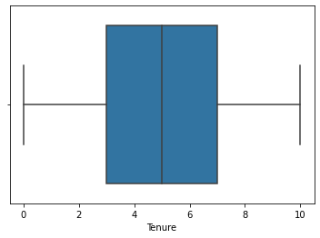

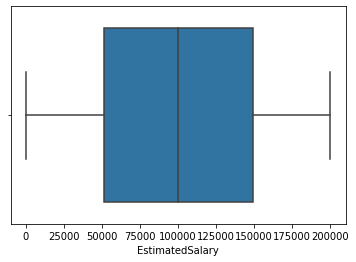

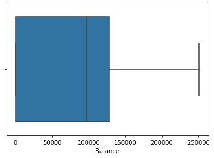

```python
for i in boxplot_col:
    sns.boxplot(data[i])
    plt.show()
```

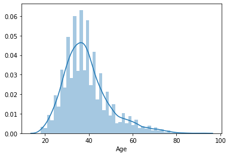

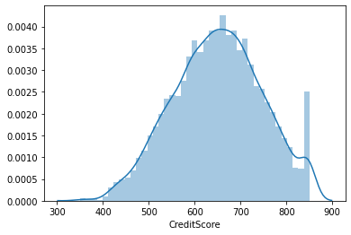

```python
for i in distplot_col:
    sns.distplot(data[i])
    plt.show()
```

```python
data[data['Age']>85] # quick Outlier treatment. No missing value treatment.
```

|  | CreditScore | Geography | Gender | Age | Tenure | Balance | NumOfProducts | HasCrCard | IsActiveMember | EstimatedSalary | Exited |
| --- | --- | --- | --- | --- | --- | --- | --- | --- | --- | --- | --- |
| 2458 | 513 | Spain | Male | 88 | 10 | 0.00 | 2 | 1 | 1 | 52952.24 | 0 |
| 6443 | 753 | France | Male | 92 | 3 | 121513.31 | 1 | 0 | 1 | 195563.99 | 0 |
| 6759 | 705 | France | Male | 92 | 1 | 126076.24 | 2 | 1 | 1 | 34436.83 | 0 |

```python
data.drop([2458,6443,6759], axis=0, inplace = True)
```

```python
# data[data['CreditScore']>850]
data[data['CreditScore']==850]['Exited'].value_counts()
```

```
0    190
1     43
Name: Exited, dtype: int64
```

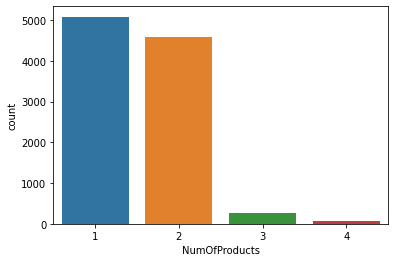

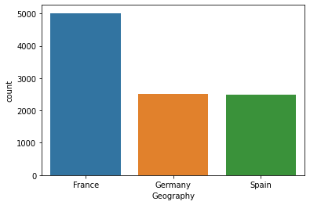

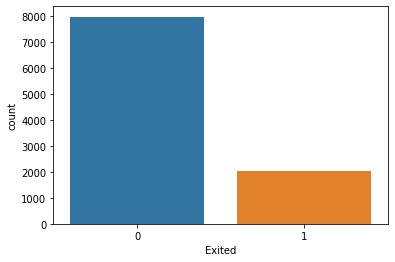

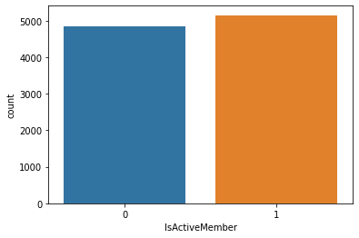

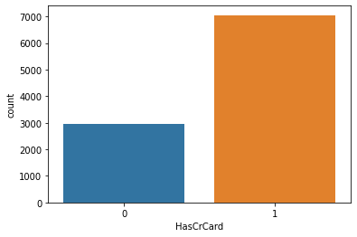

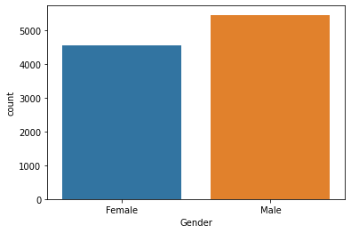

```python
for i in cat_col:
    sns.countplot(data[i])
    plt.show()
```

Overall data is balanced. Predicted value is unbalanced and couple columns are unbalanced.

1. More French customers.
2. More customers have credit card.
3. Number of Products are mostly 1 or 2.

Action: Consider Age > 85 as more extreme Outliers.  
Since 850 is the highest credit score you can get, leave them as it is.

### Bivariate EDA:

```python
data.corr()
```

|  | CreditScore | Age | Tenure | Balance | NumOfProducts | HasCrCard | IsActiveMember | EstimatedSalary | Exited |
| --- | --- | --- | --- | --- | --- | --- | --- | --- | --- |
| CreditScore | 1.000000 | -0.004137 | 0.001240 | 0.005974 | 0.012407 | -0.005241 | 0.025640 | -0.001613 | -0.027089 |
| Age | -0.004137 | 1.000000 | -0.009788 | 0.028222 | -0.031123 | -0.011611 | 0.084357 | -0.007108 | 0.287135 |
| Tenure | 0.001240 | -0.009788 | 1.000000 | -0.011887 | 0.013358 | 0.022463 | -0.028339 | 0.007886 | -0.014023 |
| Balance | 0.005974 | 0.028222 | -0.011887 | 1.000000 | -0.304152 | -0.014723 | -0.010115 | 0.012673 | 0.118568 |
| NumOfProducts | 0.012407 | -0.031123 | 0.013358 | -0.304152 | 1.000000 | 0.002938 | 0.009546 | 0.014519 | -0.047791 |
| HasCrCard | -0.005241 | -0.011611 | 0.022463 | -0.014723 | 0.002938 | 1.000000 | -0.011844 | -0.009554 | -0.007152 |
| IsActiveMember | 0.025640 | 0.084357 | -0.028339 | -0.010115 | 0.009546 | -0.011844 | 1.000000 | -0.011397 | -0.156009 |
| EstimatedSalary | -0.001613 | -0.007108 | 0.007886 | 0.012673 | 0.014519 | -0.009554 | -0.011397 | 1.000000 | 0.012085 |
| Exited | -0.027089 | 0.287135 | -0.014023 | 0.118568 | -0.047791 | -0.007152 | -0.156009 | 0.012085 | 1.000000 |

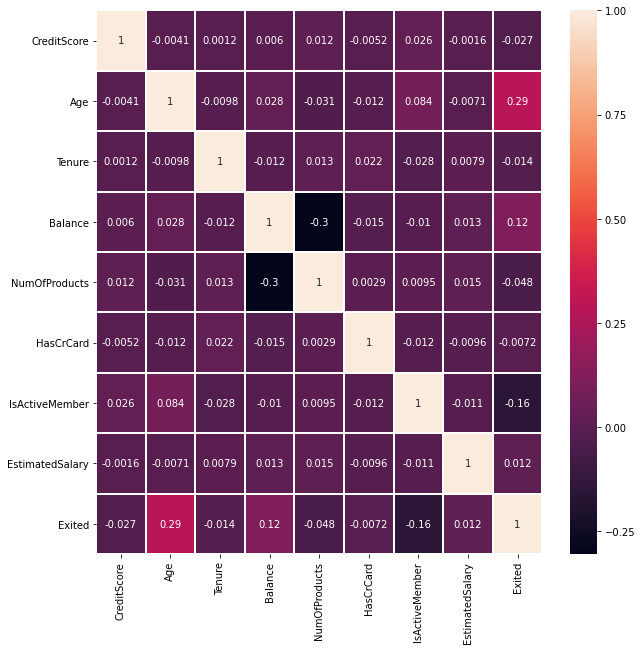

```python
plt.subplots(figsize=(10,10))
sns.heatmap(data.corr(), annot =True, linewidth=1)
```

There is no Linear Correlation between variables. No correlation in variables is good when approached with machine learning.

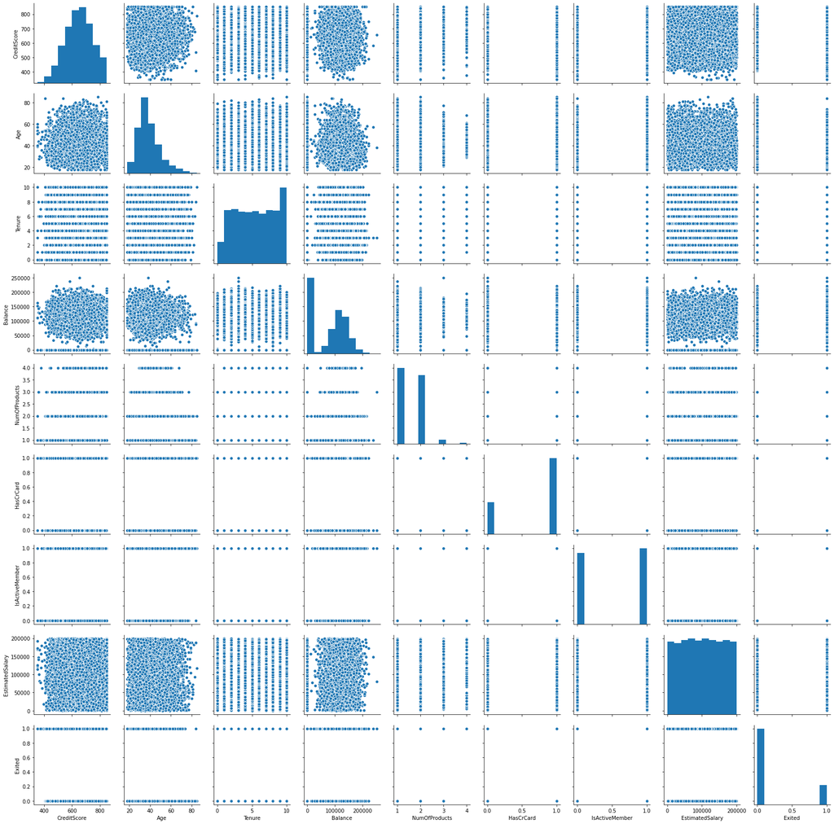

```python
sns.pairplot(data)
```

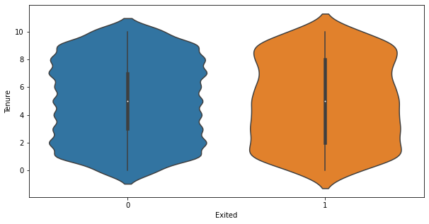

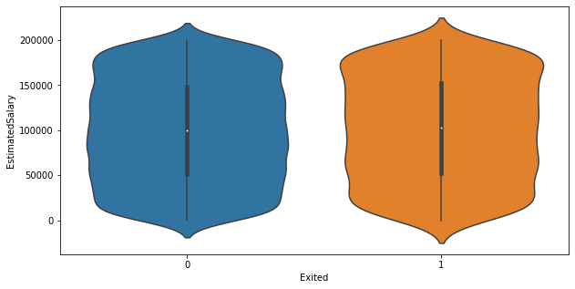

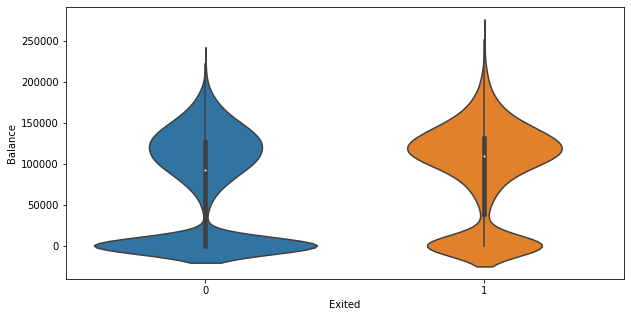

```python
for i in boxplot_col:
    plt.figure(figsize=(10,5))
    sns.violinplot(x=data['Exited'], y=data[i])
    plt.show()
```

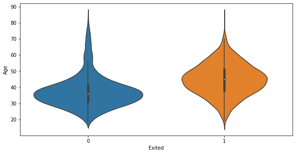

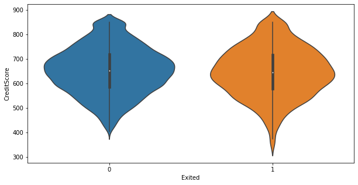

```python
for i in distplot_col:
    plt.figure(figsize=(10,5))
    sns.violinplot(x=data['Exited'], y=data[i])
    plt.show()
```

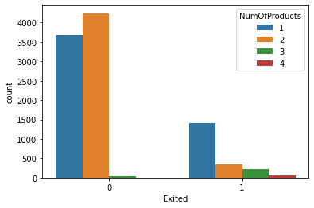

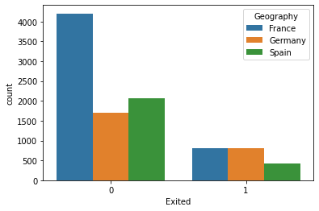

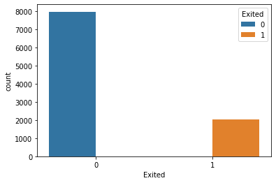

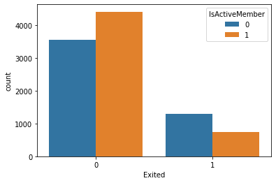

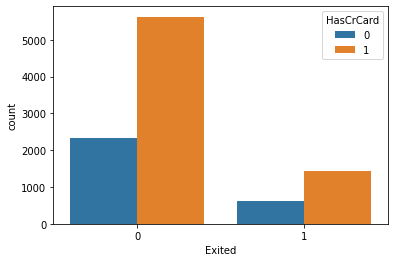

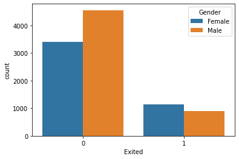

```python
for i in cat_col:
    sns.countplot(data['Exited'], hue = data[i])
    plt.show()
```

### Bivariate Insights:

1. Females are more likely to leave than males
2. Non-active members are more likely to leave.
3. German are most likely to leave compared to French and Spanish
4. Customers with higher balnace are slightly more likely to leave.
5. Customers start to leave around age of 35. 40 and above leave a lot more

## Data Pre-Processing

### Dummy variables:

```python
data = pd.get_dummies(data, columns=['Geography','Gender'],drop_first=True)
```

### Data Rescale:

```python
all_col = ['CreditScore','Age','Tenure','Balance','NumOfProducts','HasCrCard','IsActiveMember','EstimatedSalary',
           'Geography_Germany','Geography_Spain','Gender_Male']
scaler = StandardScaler()
copy_data = data[all_col].copy() # we might need to use data again later, so don't change it
copy_data_scaled = scaler.fit_transform(copy_data)
scaled_data = pd.DataFrame(copy_data_scaled, columns=copy_data.columns)
scaled_data.head()
```

|  | CreditScore | Age | Tenure | Balance | NumOfProducts | HasCrCard | IsActiveMember | EstimatedSalary | Geography_Germany | Geography_Spain | Gender_Male |
| --- | --- | --- | --- | --- | --- | --- | --- | --- | --- | --- | --- |
| 0 | -0.326209 | 0.296039 | -1.041920 | -1.225797 | -0.911474 | 0.646074 | 0.970525 | 0.021858 | -0.578852 | -0.57377 | -1.095686 |
| 1 | -0.440026 | 0.200349 | -1.387739 | 0.117377 | -0.911474 | -1.547811 | 0.970525 | 0.216522 | -0.578852 | 1.74286 | -1.095686 |
| 2 | -1.536810 | 0.296039 | 1.032995 | 1.333059 | 2.527018 | 0.646074 | -1.030370 | 0.240678 | -0.578852 | -0.57377 | -1.095686 |
| 3 | 0.501552 | 0.008969 | -1.387739 | -1.225797 | 0.807772 | -1.547811 | -1.030370 | -0.108957 | -0.578852 | -0.57377 | -1.095686 |
| 4 | 2.063952 | 0.391729 | -1.041920 | 0.785743 | -0.911474 | 0.646074 | 0.970525 | -0.365338 | -0.578852 | 1.74286 | -1.095686 |

### Data Split:

```python
X = scaled_data
Y = data[['Exited']]

#Splitting data in train and test sets
X_train, X_test, y_train, y_test = train_test_split(X,Y, test_size=0.30, random_state = 1)
```

```python
X.head()
```

|  | CreditScore | Age | Tenure | Balance | NumOfProducts | HasCrCard | IsActiveMember | EstimatedSalary | Geography_Germany | Geography_Spain | Gender_Male |
| --- | --- | --- | --- | --- | --- | --- | --- | --- | --- | --- | --- |
| 0 | -0.326209 | 0.296039 | -1.041920 | -1.225797 | -0.911474 | 0.646074 | 0.970525 | 0.021858 | -0.578852 | -0.57377 | -1.095686 |
| 1 | -0.440026 | 0.200349 | -1.387739 | 0.117377 | -0.911474 | -1.547811 | 0.970525 | 0.216522 | -0.578852 | 1.74286 | -1.095686 |
| 2 | -1.536810 | 0.296039 | 1.032995 | 1.333059 | 2.527018 | 0.646074 | -1.030370 | 0.240678 | -0.578852 | -0.57377 | -1.095686 |
| 3 | 0.501552 | 0.008969 | -1.387739 | -1.225797 | 0.807772 | -1.547811 | -1.030370 | -0.108957 | -0.578852 | -0.57377 | -1.095686 |
| 4 | 2.063952 | 0.391729 | -1.041920 | 0.785743 | -0.911474 | 0.646074 | 0.970525 | -0.365338 | -0.578852 | 1.74286 | -1.095686 |